# TBR Database

Megan Romero

2024-11-17

## Introduction

Welcome to my ever-growing pile of crazy, stupid, and/or ridiculous stories I will probably never read. This is a showcase of my TBR (To Be Read) list—a collection of books that I have impulsively plucked off the shelves of the internet and have thrown into this magnificent database. And while analyzing this database, we can together uncover the various trends and truths of my horrible taste.

*“What does my TBR say about me?”* Self-centered question, I know— but this is the database I’ve got. 💀

I’ll be using metrics like location, time period, tropes, genres and more to create graphs and answer questions which can show not only the trends over time when it comes to my preference, but the preferences of the publishing industry at large.

[link to romance.io](https://www.romance.io/)

#### Packages & Prep

This absolute monster of a database was created and curated by me, with the help of the greatest website ever made (and it’s wonderful user base), romance.io— created by Silke.

Romance.io uses a one-of-a-kind tagging system that allows users to crowd source information on their favorite books. Users can go to any book’s page and tag whatever tropes they feel fits. You can even upvote and downvote any tags other users have left!

Of course, due to the nature of crowd sourcing information, not every book will be entirely accurate in it’s tags, and books that are less popular or are very old are much more likely to be missing tags or other information. We see this in the upcoming charts.

```r
Bookbase <- read.csv("TBR Database Final Version.csv")
```

```r
library(tidyverse)
library(dplyr)
library(maps)
library(knitr)
library(tidyr)
library(ggplot2)
library(ggrepel)
library(ggforce)
library(packcircles)
library(scales)
library(lubridate)
library(timevis)
```

Let’s take a quick look at the data:

```r
Condensed_Glimpse <- Bookbase %>%
  select(Title, Author, Series, Romance.io.Rating, X..of.Ratings, X..of.Reviews, Release.Date, Page.Count)
glimpse(Condensed_Glimpse)
```

```
## Rows: 1,666
## Columns: 8
## $ Title             <chr> "Nobody's Baby But Mine", "Billionaire Unloved: Jett…
## $ Author            <chr> "Susan Elizabeth Phillips", "J.S. Scott", "Melissa F…
## $ Series            <chr> "Chicago Stars", "The Billionaire's Obsession ", "Th…
## $ Romance.io.Rating <dbl> 3.98, 4.51, 4.35, 3.92, 3.83, 3.11, 4.09, 4.19, 4.33…
## $ X..of.Ratings     <int> 132, 15, 14, 30, 6, 9, 10, 118, 3, 29, 1, 181, 2, 13…
## $ X..of.Reviews     <int> 6, 1, 0, 1, 0, 0, 0, 7, 0, 1, 0, 11, 0, 0, 0, 1, 6, …
## $ Release.Date      <chr> "1-Feb-97", "28-Feb-18", "13-Jul-14", "26-Dec-18", "…
## $ Page.Count        <int> 374, 228, 300, 186, 329, 354, 180, 288, 402, 400, 31…
```

pretty standard… - >-

### To give you a better idea…

There are a total of 332 tags which are broken up into 6 categories.

These are the 3 most popular tags in every category:

[output not shown]

### To showcase a final caveat…

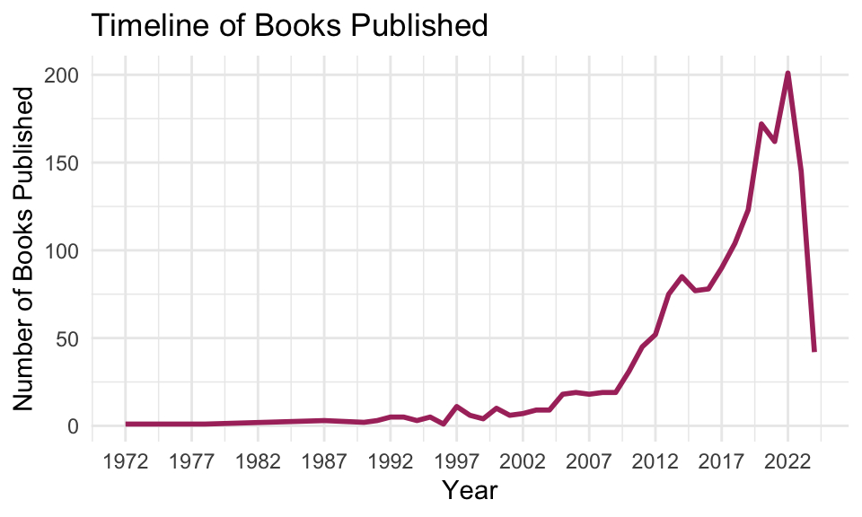

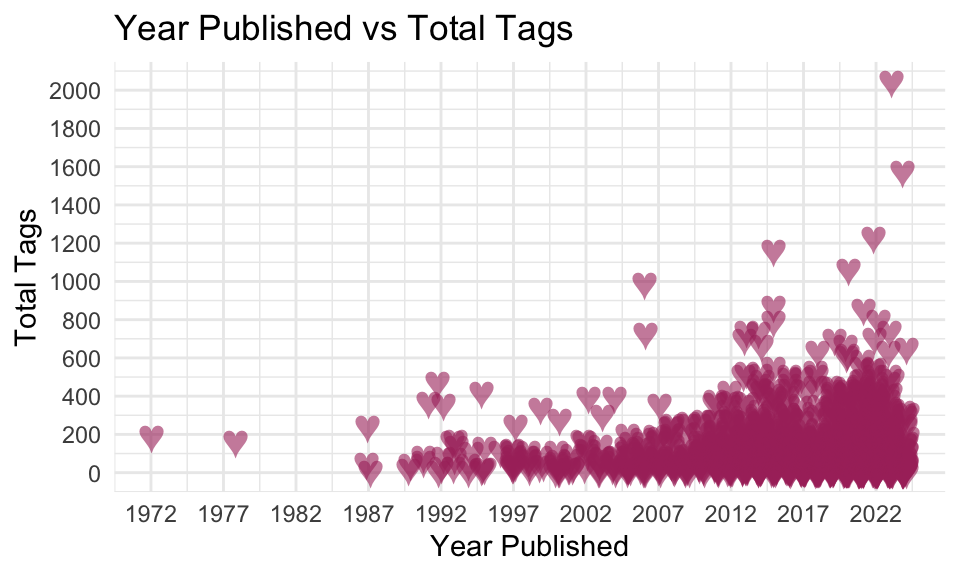

Clearly, when we compare the date a book was published versus the amount of tags it has, we see that there’s definitely a correlation between recency and a higher amount of tags.

### Now that we’ve established our data, let’s dive into some stats 👹

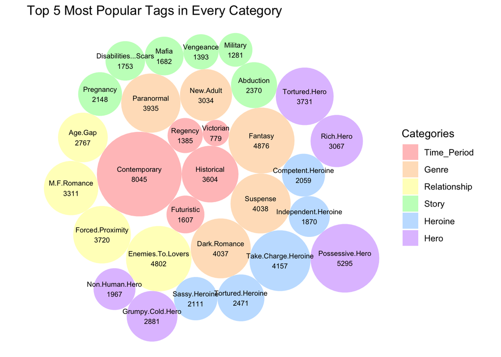

From this chart, we can see that there’s not really one category to outweigh all. People aren’t just tagging the time period and being over it.

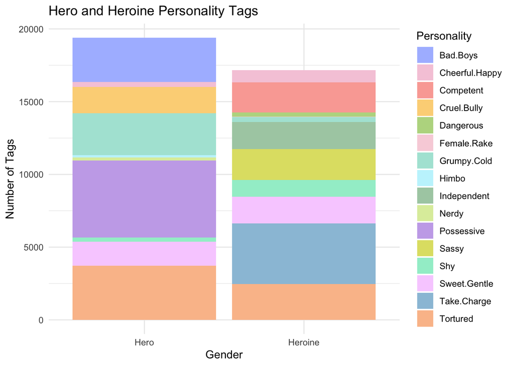

As with most things in life, women are *slightly* more underrepresented when it comes to available data… 😬

Tbh, I don’t know what it says about me that most of the Heroes in books that I save are either bad, cruel, cold, possessive, or tortured…

So instead, I’ll just conclude that the publishing industry at large only likes put out these traits. 💀👍

Now for occupations!

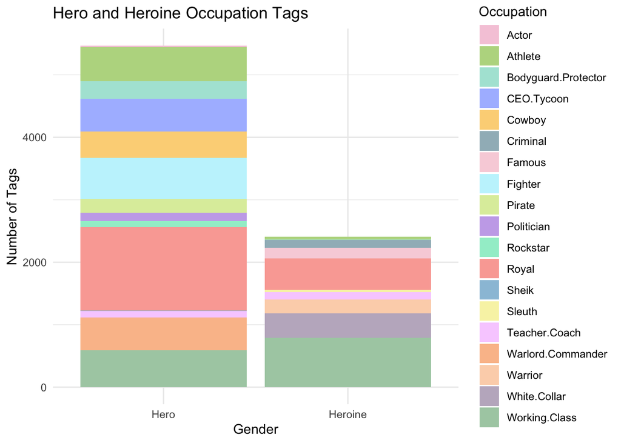

…Aaaand, to no one’s surprise, women are even ✨*less*✨ represented in this category! 🙃

But heyyy, we get to be criminals and sleuths..? 🤨🙄

At least I can actually claim responsibility for the most common occupation for men being Royalty. That actually holds up when it comes to the tropes I *actually* like. 👑💕

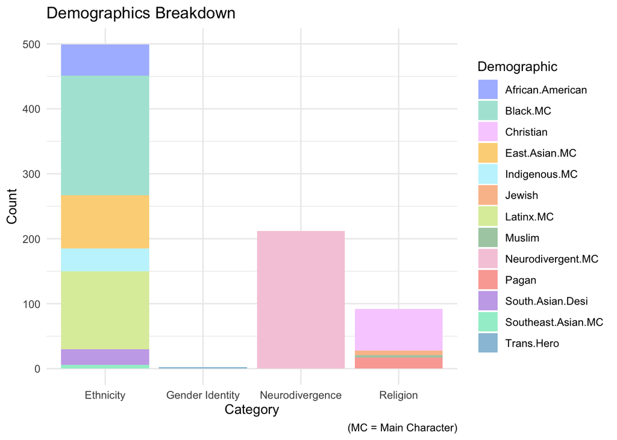

Of demographics,,,

```r
total_books
```

```
## [1] 1666
```

### 👀👀👀

Yeahhh, I’m not that diverse…

That’s wholly my L, but also- it probably should say something about the book community at large that this is the ratio of books I just come across-

Because the majority of these books came from recommendations.

And of the demographics tags, **Trans Heroine, Hindu, Buddhist, and Amish** were all nixed from the graphic because there were just straight up **0** books with those tags. 💀

### Introducing the “Megan-is-Obsessed-with-Maps” portion of the report:

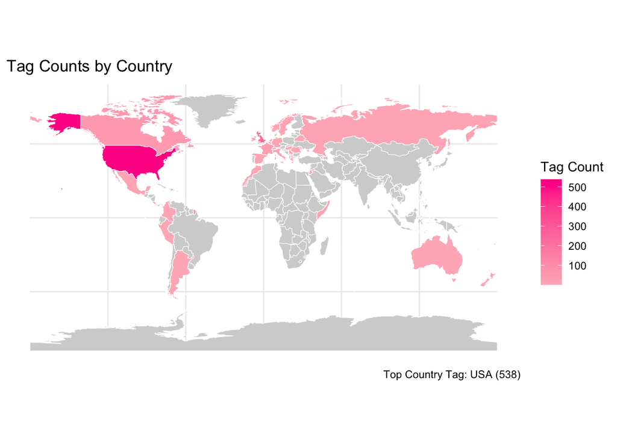

Yeah. Not a ton of individual countries are represented in the tags- U.S. is obviously #1.

Howeverrrr…

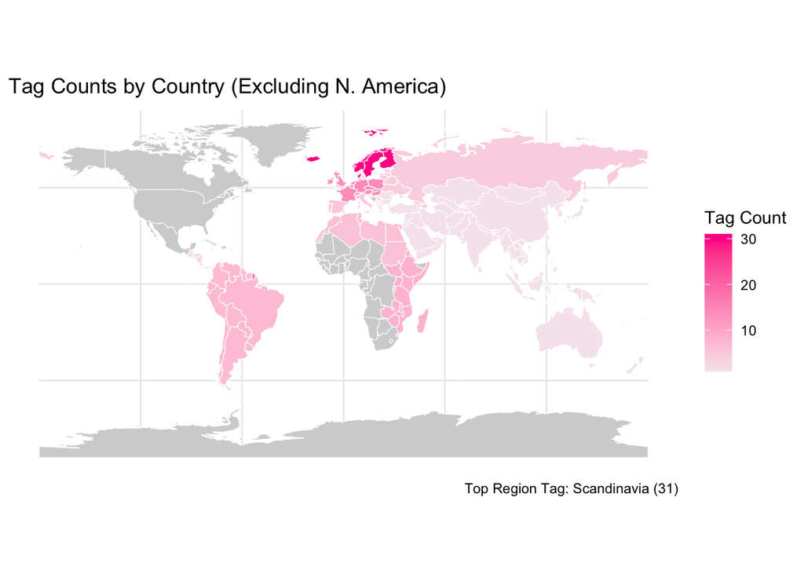

If we look at the available tags for continental regions, we get a bit more of a completed picture!

Sometimes books don’t specify the country 🤷‍♀️

Which is why it’s great that regional tasks are available.

And you might be angry at me for excluding the region tag of North America… Well I’m not angry at me, because North America was tagged 413 times… 💀

(trust me, this is better…)

[figure not shown]

Aaand, if we look at *just* the U.S., we can see a very predictable picture start to form.

*What a shock!* People like New York and California… -o-

Though funny enough Illinois is *really* popular for some reason… hmm… 🤔

### Anyway, now for the **Fun** stuff! 💕💖💗💘💝

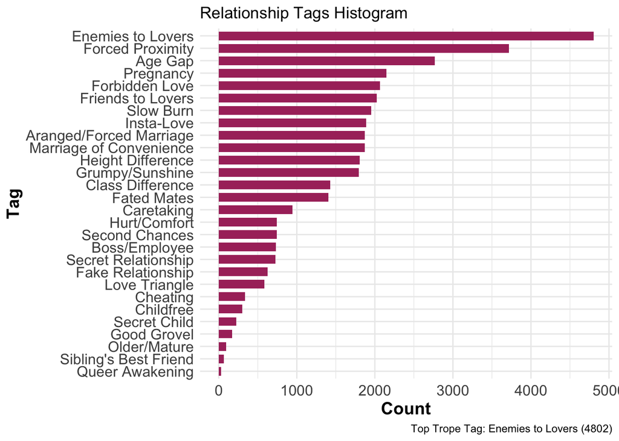

This is the chart of every available relationship *trope* tag, and clearly, Enemies to Lovers is *over*represented 😑

Seriously, this has to be indicative of what sells, because I don’t like Enemies to Lovers at all…

But, this is still my list, so comparatively…

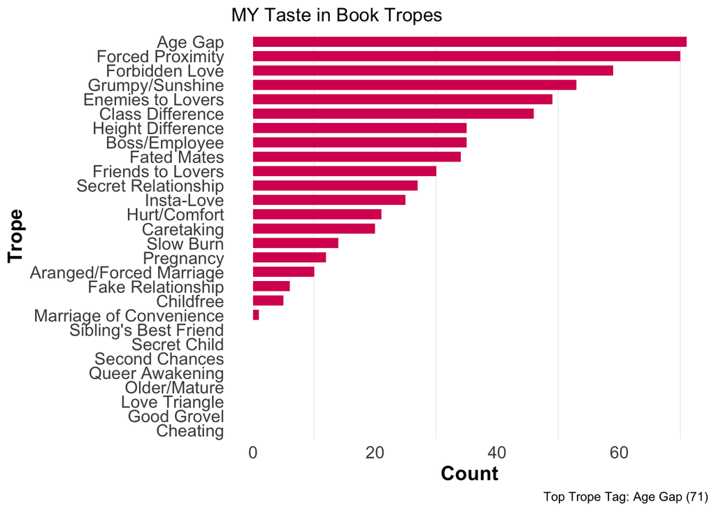

These are the top tropes of the books I’ve *actually* read already, which… I’m not going to comment on.

Other than saying, even **I** was surprised…👀

### Aaand, speaking of which:

(I promise I’m catching up next year)

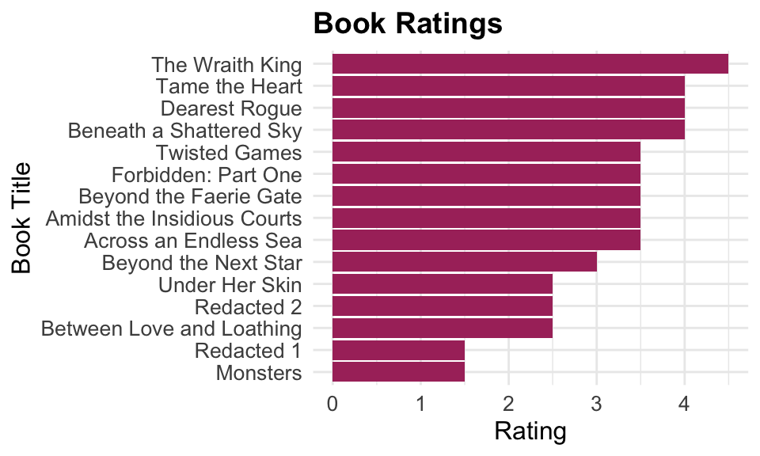

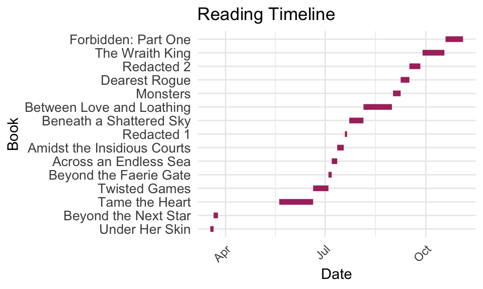

### In Summary,

I indeed have bad taste.

But at least we got to see some interesting tidbits about what might be a quirk of mine, or is something to be considered about the population of readers out there, and even what might be a flaw of the publishing trends.

Either way, I had a lot of fun doing this, and I hope you got some enjoyment out of it as well. There could very well be more conclusions to draw if given a different set of books to explore. But for now, this is me and my conclusions. 💗